# R Overview for IT

2018-01-12

## R Overview

What is R?

R is a programming environment built for statistical (data science) applications. Based on "S" and "Lisp"

- ["R"](https://www.r-project.org)
- "S"
- Lisp

More - [History of R](http://blog.revolutionanalytics.com/2017/10/updated-history-of-r.html)

## Getting R

- ["R"](https://www.r-project.org)
- [CRAN Mirrors](https://cran.r-project.org/mirrors.html)
- [CRAN Packages](https://cloud.r-project.org/web/packages/index.html)

## R - under the hood

- Base
- Stats
- Methods (for S3 and S4 objects)
- Graphics
- Linear Algebra
  - LINPACK, LAPACK, others may be used

## Setting up a plot

[Link to Code](https://rpubs.com/filipstachura/rpackages)

```r
url <- "https://cran.r-project.org/web/packages/available_packages_by_date.html"

page <- read_html(url) %>%
  html_node("table") %>%
  html_table() %>%
  mutate(count = rev(1:nrow(.))) %>%
  mutate(Date = as.Date(Date)) %>%
  mutate(Month = format(Date, format="%Y-%m")) %>%
  group_by(Month) %>%
  summarise(published = min(count)) %>%
  mutate(Date = as.Date(as.yearmon(Month))) -> pkgs
```

## Example: Prepare plotly graph

```r
margins = list(l = 100, r = 100, b = 100, t = 100, pad = 4)

plot_pltly <- pkgs %>%
  plot_ly(x = ~Date, y = ~published, name= "Published packages",
          type="scatter", mode = "lines") %>%
  layout(title = "CRAN packages published over time.",
         margin = margins)
```

## Growth of CRAN Packages (plotly)

```r
plot_pltly
```

[interactive chart not shown]

## Example: Prepare ggplot graph

```r
plot_gg <- pkgs %>%
  ggplot(aes(x = Date, y = published)) +
  geom_point(color = 'dark cyan') +
  geom_line(color = 'red') +
  scale_x_date(date_breaks = "years", date_labels = "%Y") +
  theme(axis.text.x = element_text(angle = 90, hjust = 1)) +
  ggtitle('CRAN packages published over time')
```

## Growth of CRAN Packages (ggplot)

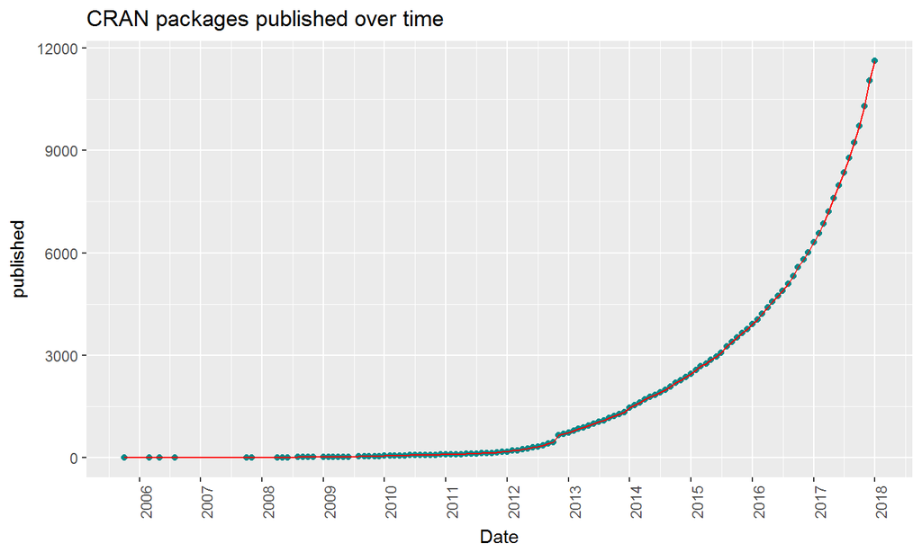

```r
plot_gg
```

## More R Characteristics

- Object Oriented
- Lists, dataframes, matrices, vectors, strings (no scalars)
- Functions, modules, packages
- Functional programming
- Hooks into other languages
  - for instance: C, C++, Fortran, Java, Perl, etc.

## Basically …

- Everything that exists in R is an object.
- Everthing that happens in R is a function call.
- Interfaces to other software are part of R.
  - [John Chambers](https://statweb.stanford.edu/~jmc4/vitae.html)

## MoRe

- Interpreted language
  - can speed up with:
    - more preprocessing in database
    - vectorized R operations
    - compiled R
    - C/C++
  - [Tips for faster R](https://robinsones.github.io/Making-R-Code-Faster-A-Case-Study/)
- Recent improvements in packages with common syntax ("Tidyverse")

## Working with R

- Development
  - R itself (R scripts)
  - IDE (R Studio, Eclipse, Visual Studio, others)
  - code version management with svn and git (github)
- Deployment
  - Use within IDE (local machine, server)
  - Batch script execution
  - Called from other platforms
  - Interactive application
- [Data Science Workflow and R](https://speakerdeck.com/jennybc/workflow-you-should-have-one)

## Getting data

- Excel, csv, tab delimited
- Web scraping
- SharePoint (XML, JSON)
- Various APIs (Google, Yahoo Finance, FRED, NOAA, etc etc)
- SQL options
  - MS Access (if we must)
  - SQL Server (connects externally; is also built into)
  - Oracle (connects externally; is also built into)
  - MySQL
  - Others: PostGres, NoSQL, MariaDB
  - etc. (pretty much any DB system where we can define a connection string)

## Support

- [r-project.org](https://www.r-project.org/help.html)
- [Stackoverflow](https://stackoverflow.com/questions/tagged/r)
- [R Community](http://fg2re.sellorm.com/community.html)
- [R Studio community](https://community.rstudio.com/)
- [R-bloggers Learning R](https://www.r-bloggers.com/how-to-learn-r-2/)
- Many social media groups (Twitter, Google+, others)
- Many, many sites devoted to using R (UCLA IDRE; cookbook-R, etc etc etc)

## Enterprise

- R Studio Enterprise
- Revolution R Enterprise (Microsoft)
- Similar - S Plus (Tibco Software)
- R within Microsoft SQL Server
- R within Oracle

## Making results available

- Report writing
  - can write to MS Word, PowerPoint
  - can create pdf docs, ioslides, slidify, etc
  - can create text and rtf docs
  - markdown
  - notebooks (similar to Jupyter)
- Reading and writing from/to Excel, Googlesheets
- Can send e-mails, publish social media (Twitter)
- Web publishing and web apps

## Does R do graphs?

[R Graph Gallery](https://www.r-graph-gallery.com/all-graphs/)

- Popular
  - base R plotting (very powerful)
  - ggplot2
    - based on Cleveland's 'Grammer of Graphics'
    - [some examples](http://r-statistics.co/Top50-Ggplot2-Visualizations-MasterList-R-Code.html)
    - [extensions to ggplot2](http://www.ggplot2-exts.org/gallery/)
  - [plotly](https://plot.ly/)
  - integration with javascript libraries (d3.js, raphael)
- Many, many others

## Data Mining and Machine Learning

- Methods (a few)
  - ANOVA, Linear Regression, Logistic Regression
  - Principle Components Analysis, Factor Analysis, Discriminant Analysis
  - Cluster Analysis, Neural Networks, Bayesian methods
  - Text Mining and Sentiment Analysis
  - Support Vector Machines, Random Forests, Gradient Boosting, Ensemble Methods
  - Time Series and Forecasting
- Machine Learning Integration
  - Keras, Tensorflow, MS Azure, Spark, Hadoop, options for parallel processing

## Web publishing options

- [OpenCPU](https://www.opencpu.org/)
  - HTML/CSS/Java/JavaScript
- [Shiny with Shiny Server](https://shiny.rstudio.com/)
  - Translates (sort of) R code to HTML, CSS, Java, Javascript
  - Very popular, growing in use and capabilities
  - Provides static and dynamic/interactive reporting and app development
  - Shiny development is fast, flexible
  - Can run on any OS; currently using Linux server at Essendant

## Web publishing examples

- [Shiny Gallery Examples](http://shiny.rstudio.com/gallery/)
  - [flexible web layout options](https://shiny.rstudio.com/articles/layout-guide.html)
    - sidebar, fluid grid system, tabsets, nav lists, navbar pages
  - [themes and bootstrap](http://rstudio.github.io/shinythemes/)
  - [Shiny Dashboard structure](https://rstudio.github.io/shinydashboard/)

## Is R popular?

- [IEEE Rankings 2017](https://spectrum.ieee.org/computing/software/the-2017-top-programming-languages) [(Interactive)](https://spectrum.ieee.org/static/interactive-the-top-programming-languages-2017)
- [TIOBE Rankings 2017](https://www.tiobe.com/tiobe-index/)
- [Article on Data Science Software](http://r4stats.com/articles/popularity/)

## More Reading

- [Six Reasons to Use R for Business](https://www.r-bloggers.com/six-reasons-to-learn-r-for-business/)
- [Field Guide to the R Ecosystem](http://fg2re.sellorm.com/)

## QUESTIONS ?

## Rotatable 3D Plot

[interactive chart not shown]

## This presentation:

- Created with
  - R
  - rmarkdown (markdown package with inline R functionality)
    - ioslides format
    - uses knit ('knitr' package)
    - can also render to pdf (Beamer), MS Word, MS PowerPoint, slidy
    - etc etc
- Published with
  - shiny
  - shiny-server